# act_report

## Act_Report

### KEY INSIGHTS

> The data was derived from the twitter account: @rate_dogs.

> The dataset used for the project is divided into three parts:
1. Archived twitter data
2. Image prediction data
3. Retweet count and favourite count

> Anaconda's Jupyter Notebook was majorly used for this project.

> The wrangling efforts merged into the dateset into two datasets. From the main dataset that included the archived twitter data and the retweet count and favorite count data, using simple pandas functions like .value_counts(), I was able to determine that a large number of the dogs are without a name.

> Having a name personalizes the experience for users who want to have their dogs rated. I recommend creating a format in which users are to drop the information. This in addition to personalizing the experience as previously stated also even allows easy data gathering and analysis to help promote the account.

### VISUALIZATION

> There are two visualizations displayed in this report. One is a wordcount that displays the name of the species based on their count. The other is a barplot that shows the average favorite count for each of the dog stages.

> First, we import the necessary libraries needed for this and then load the dataset.

```python
# importing important libraries
import numpy as np
import pandas as pd
import matplotlib.pyplot as plt
import seaborn as sb
from wordcloud import WordCloud
```

```python
#  load the required dataset
cleaned_archived = pd.read_csv("twitter_archive_master.csv")
cleaned_image = pd.read_csv("image_prediction_master.csv")
```

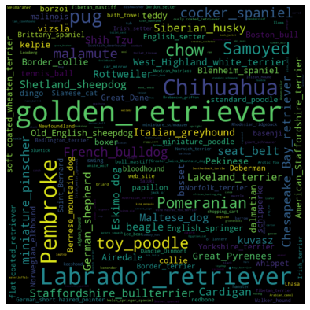

```python
#  Using a word cloud to generate the p1 names of the dogs

names = ""
for i in cleaned_image['p1']:
    names = names + i + " "

# Create the wordcloud object
wordcloud = WordCloud(width=1000, height=1000).generate(names)

# Display the generated image:
plt.figure(figsize=(12, 7))
plt.imshow(wordcloud, interpolation='bilinear')
plt.axis("off")
plt.margins(x=0, y=0)
```

> I quite like the art form of this visualization. It reveals that the golden retriever dogs are the most common species followed by the Labrador retriever and the Pembroke. Notable mentions also include the Chihuahua, toy poodle, Samoyed, Pug.

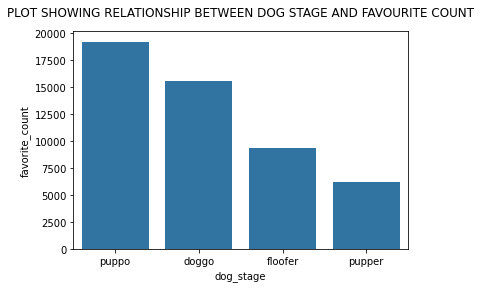

```python
# query the dog stages in the dogtionary
dog_viz = cleaned_archived.apply(lambda x: x[cleaned_archived['dog_stage'].isin(['doggo', 'puppo', 'floofer', 'pupper'])])

# plot a relationship between dog stage and favorite count.
order = ['puppo', 'doggo', 'floofer', 'pupper' ]
color=sb.color_palette()[0]
sb.barplot(data=dog_viz, x='dog_stage', y='favorite_count', ci=None, order=order, color=color)
plt.title("PLOT SHOWING RELATIONSHIP BETWEEN DOG STAGE AND FAVOURITE COUNT", pad=15);
```

> The different dog stages can be checked [here](https://en.wikipedia.org/wiki/DoggoLingo)

> In conclusion, this report has provided key insights into the two datasets derived and from @rate_dogs twitter account. It has also through visualization presented a relationship between the variables and also keyed in on one of the insights.